# MI Wave 1 analyses: JNeuro reanalysis/replication

# 1 intro

```r
## libraries ----

library(here)
library(data.table)
source(here("src", "stroop-rsa-pc.R"))
library(knitr)
library(dplyr)
library(tidyr)
library(ggplot2)
library(mfutils)
library(ggseg)
library(ggsegExtra)
library(ggsegSchaefer)
library(ggsegGlasser)

## settings, params ----

opts_chunk$set(echo = TRUE, out.width = "100%")
theme_set(theme_bw(base_size = 10))

if (exists("params")) {
  ttype_subset <- params$ttype_subset
  prewh <- params$prewh
  measure <- params$measure
  roiset <- params$roiset
} else {
  ttype_subset <- "bias"
  prewh <- "obsall"
  measure <- "cveuc"
  roiset <- "glasser2016_parcel"
}

theme_surface <- list(
  theme(
    axis.text = element_blank(), panel.grid = element_blank(), panel.border = element_blank(),
    axis.ticks = element_blank(), legend.position = c(0.5, 0.5), legend.title = element_text(size = 5),
    legend.background = element_blank(), legend.text = element_text(size = 5), legend.direction = "horizontal",
    legend.key.height = unit(1/5, "cm"), legend.key.width = unit(1/4, "cm")
  )
)


## constants ----

wd <- here()
subjlists <- "mi1"
seswaves <- c("proactive_wave1")
glmname <- "lsall_1rpm"
sessions <- c("proactive")
statistics <- c("m", "t_stat")
titles <- c("mean coefficient", "t statistic")


## data ----

## read regression weights:

dat <- Map(
  function(subjlist, suffix) {
    fname <- construct_filename_weights(
        measure = measure, subjlist = subjlist, glmname = glmname,
        ttype_subset = ttype_subset, roiset = roiset, prewh = prewh, suffix = suffix
        )
    fread(fname)
  },
  subjlist = subjlists,
  suffix = paste0("__seswave-", seswaves)
)
dat <- rbindlist(dat)


## get ggseg atlas and format data to match:

dat <- dat %>% rename(region = roi)

if (roiset == "schaefer2018_17_200_parcel") {

  atlas <- schaefer17_200
  k <- schaefer2018_17_200_fsaverage5$key %>% select(region = parcel, network)

  rois <- data.frame(
    region = c(
    "17Networks_LH_ContA_PFClv_1",
    "17Networks_LH_ContA_PFCl_1",
    "17Networks_LH_ContA_PFCl_2",
    "17Networks_LH_ContA_PFCl_3",
    "17Networks_RH_ContA_PFCl_1",
    "17Networks_RH_ContA_PFCl_2",
    "17Networks_LH_SalVentAttnB_PFCmp_1",
    "17Networks_RH_SalVentAttnB_PFCmp_1",
    "17Networks_LH_SalVentAttnA_FrMed_1",
    "17Networks_RH_SalVentAttnA_FrMed_1"
    ),
    location = c(rep("lateral", 6), rep("medial", 4))
  )

} else if (roiset == "glasser2016_parcel") {

  atlas <- glasser
  k <- glasser2016_fsaverage5$key %>% select(region = parcel, network)

  dat <- dat %>% filter(!region %in% "L_10pp")  ## not in glasser ggseg atlas?
  ## create region column in ggseg atlas that matches data:
  hemi <- ifelse(atlas$data$hemi == "left", "L_", "R_")
  atlas$data$region <- ifelse(is.na(atlas$data$region), NA, paste0(hemi, atlas$data$region))

  rois <- data.frame(
    region = combo_paste(c("L_", "R_"), c("SCEF", "8BM",  "p32pr", "a32pr", "p9-46v", "i6-8", "8Av", "8C")),
    location = c(rep("medial", 8), rep("lateral", 8))
  )

}

## add network information:
atlas$data <- left_join(atlas$data, k, by = "region")
dat <- left_join(dat, k, by = "region")


## calculate ----

## add subject set information:
subjlists <- rbind(
  data.table(subjlist = "jneurosci", subject = fread(here("out", "subjlist_jneurosci_primary.txt"))[[1]]),
  data.table(subjlist = "replication", subject =
               fread(here("out", "subjlist_jneurosci_replication_primary.txt"))[[1]])
)
dat_subjs <- dat %>% inner_join(subjlists, by = "subject")
dat_subjs <- bind_rows(dat_subjs, dat_subjs %>% mutate(subjlist = "jneurosci \u222A replication"))

dat_sum <- dat_subjs %>%
  group_by(subjlist, session, term, wave, region) %>%
  summarize(
    m = mean(b),
    t_stat = t.test(b)$statistic,
    p = t.test(b, alternative = "greater")$p.value,
    .groups = "drop_last"
    ) %>%
  mutate(p_fdr = p.adjust(p, "fdr"))

dat_sum <- dat_sum %>% filter(term %in% models[[measure]])

n_subjs <- table(unique(dat_subjs[, c("subject", "subjlist")])$subjlist)
```

This file displays group-level RSA model coefficients (means, test statistics).

**Analysis parameters**:

**Subject samples**:

Analyses are conducted with three different sets of subjects.

- the **jneurosci** set: N = 46, unrelated
  - The paper had N=49; 3 subjects are not included in these analyses: 873968, DMCC1971064, DMCC9478705
  - the latter subject is not included due to failed fmriprep preprocessing
  - the former two subjects were unintentionally excluded due to meeting jo’s criteria for “bad runs”: >20% of TRs excluded due to high motion (I am running these subjects now)
- the **replication** set: N = 21, unrelated (to each other and to those in jneurosci)
- the **jneurosci** $\bigcup$ **replication** set: N = 67, unrelated

# 2 Brains

## 2.1 Unthresholded

### 2.1.1 Common scale

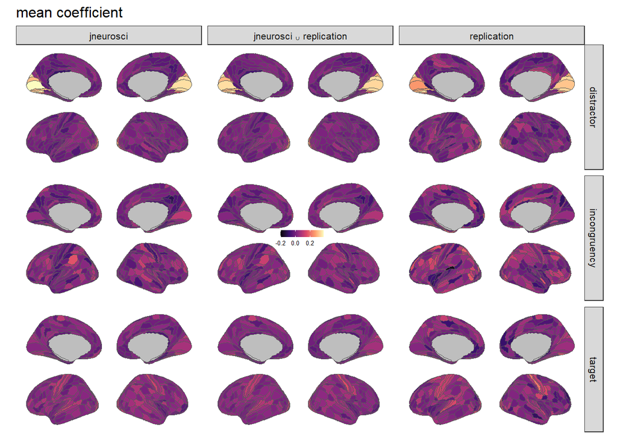

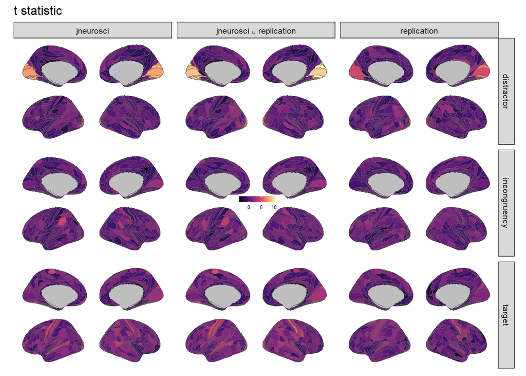

```r
for (stat_i in seq_along(statistics)) {

  p <- dat_sum %>%
    ggplot() +
    geom_brain(
      aes_string(fill = statistics[stat_i]),
      atlas = atlas, position = position_brain(side ~ hemi)
      ) +
    scale_fill_viridis_c(
      option = "magma", na.value = "grey",
      breaks = scales::extended_breaks(4)
      ) +
    facet_grid(rows = vars(term), cols = vars(subjlist)) +
    theme_surface +
    labs(title = titles[stat_i], fill = NULL)

  print(p)

}
```

### 2.1.2 Separate scales by model

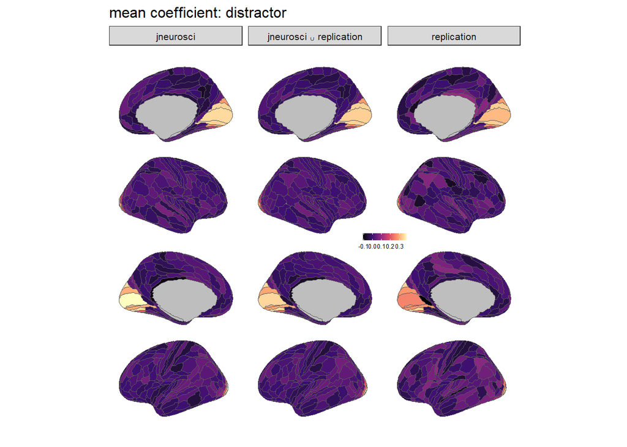

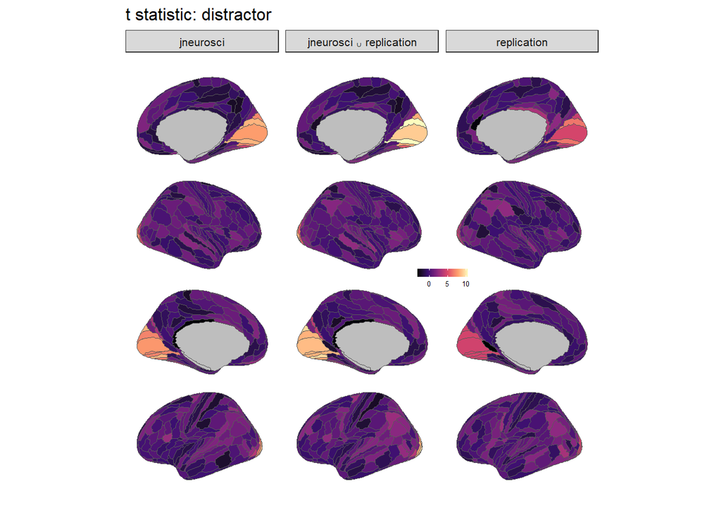

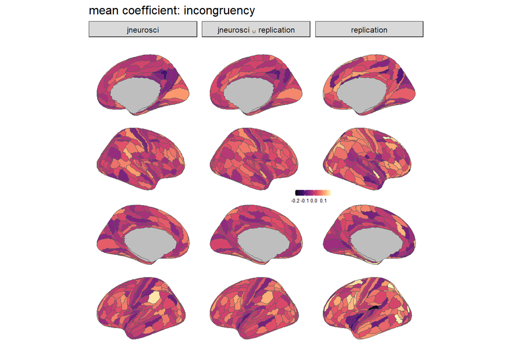

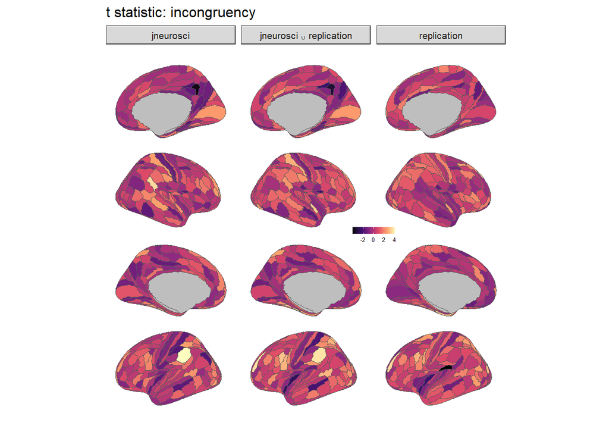

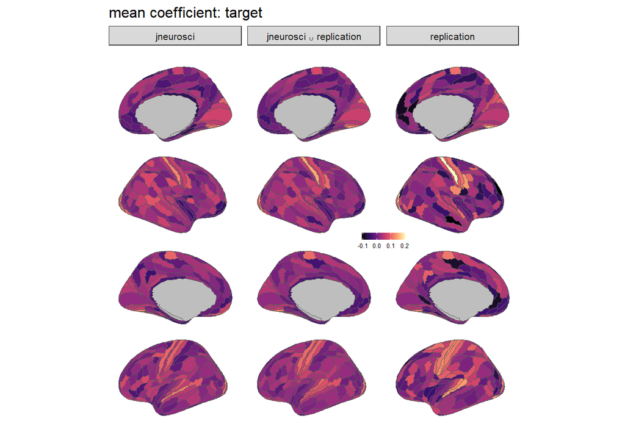

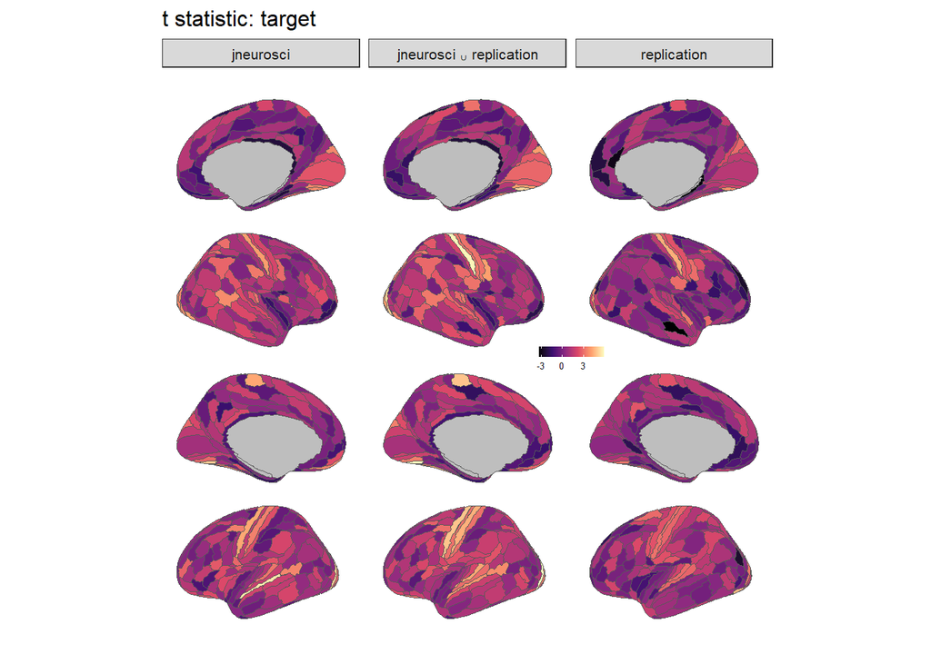

```r
for (model_i in seq_along(models[[measure]])) {

  model <- models[[measure]][model_i]

  for (stat_i in seq_along(statistics)) {

    p <- dat_sum %>%
      filter(term %in% model) %>%
      ggplot() +
      geom_brain(
        aes_string(fill = statistics[stat_i]),
        atlas = atlas, position = position_brain(hemi + side ~ .)
        ) +
      scale_fill_viridis_c(
        option = "magma", na.value = "grey",
        breaks = scales::extended_breaks(4)
        ) +
      facet_grid(cols = vars(subjlist)) +
      theme_surface +
      theme(legend.position = c(2/3, 0.5)) +
      labs(title = paste0(titles[stat_i], ": ", model), fill = NULL)

    print(p)

  }

}
```

## 2.2 Thresholded

Three consecutive thresholds are used, each more liberal than the previous:

- **p_FDR < 0.05**: parcels with mean model fit significantly greater than 0 following FDR correction over all parcels (separately per model)
- **p_uncorr < 0.05**: parcels with mean model fit significantly greater than 0 (uncorrected)
- **t_stat > 0**: parcels with mean model fit numerically greater than zero

### 2.2.1 Common scale

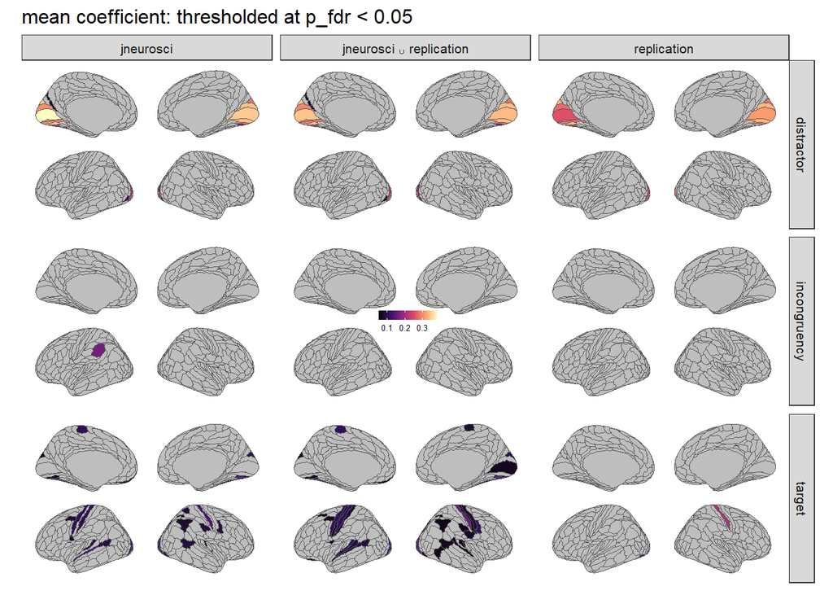

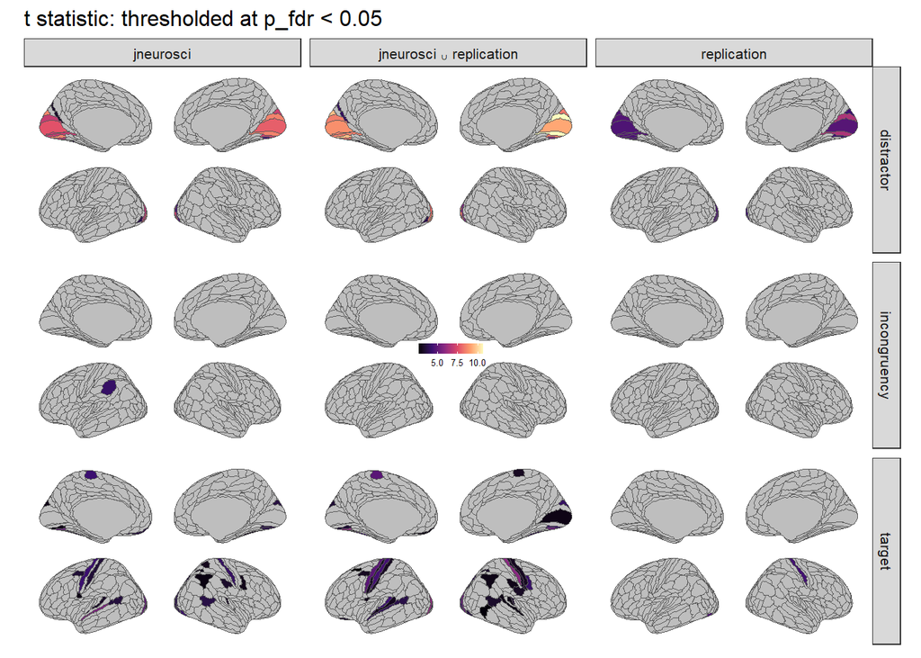

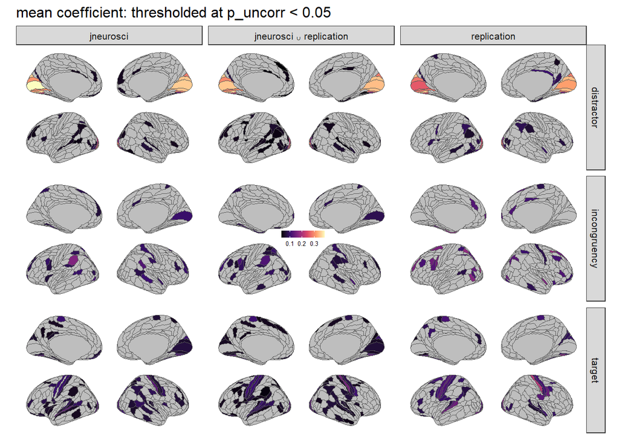

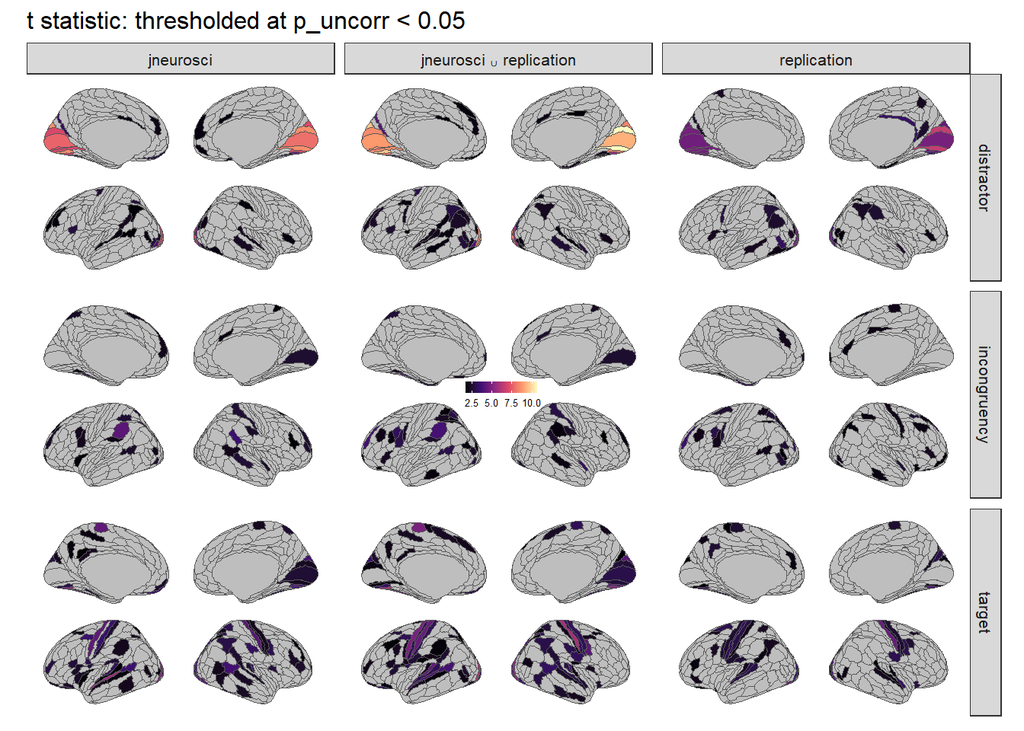

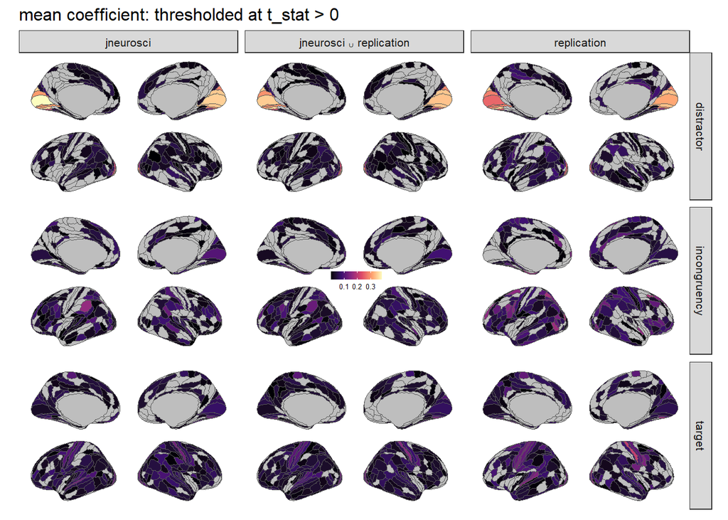

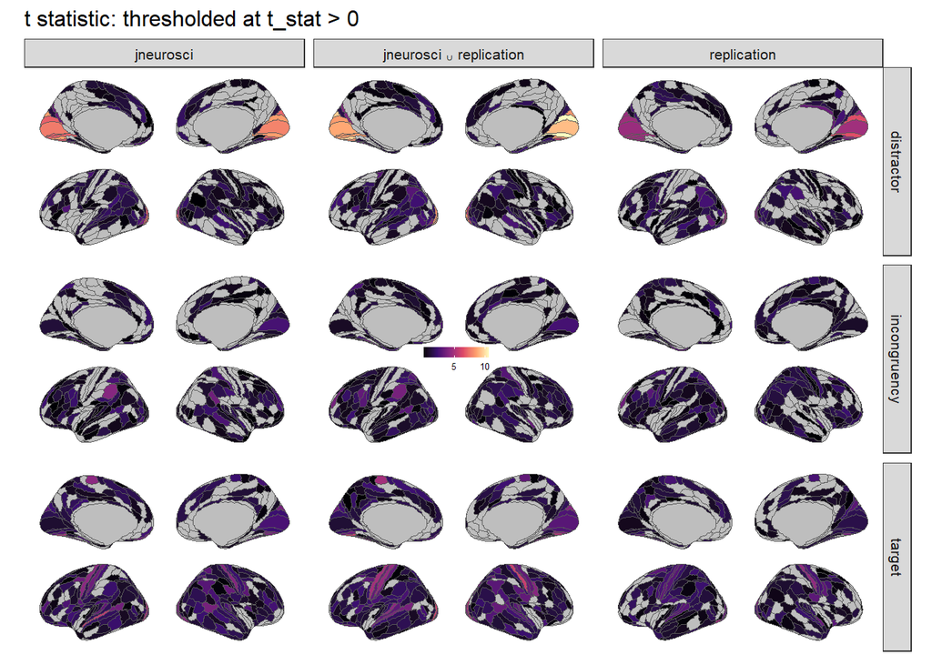

```r
dat_sum$is_in_thresh_fdr <- dat_sum$p_fdr < 0.05
dat_sum$is_in_thresh_p <- dat_sum$p < 0.05
dat_sum$is_in_thresh_sign <- dat_sum$t_stat > 0

thresholds <- c("p_fdr < 0.05", "p_uncorr < 0.05", "t_stat > 0")
thresholds_nms <- c("is_in_thresh_fdr", "is_in_thresh_p", "is_in_thresh_sign")

for (thresh_i in seq_along(thresholds)) {

  threshold_nm <- thresholds_nms[thresh_i]

  for (stat_i in seq_along(statistics)) {

    dat_sum$thresh <- as.numeric(ifelse(dat_sum[[threshold_nm]], dat_sum[[statistics[stat_i]]], NA))

    p <- dat_sum %>%
      ggplot() +
      geom_brain(
        aes(fill = thresh),
        atlas = atlas, position = position_brain(side ~ hemi)
        ) +
      scale_fill_viridis_c(
        option = "magma", na.value = "grey",
        breaks = scales::extended_breaks(4)
        ) +
      facet_grid(rows = vars(term), cols = vars(subjlist)) +
      theme_surface +
      labs(title = paste0(titles[stat_i], ": thresholded at ", thresholds[thresh_i]), fill = NULL)

    print(p)

  }

}
```

# 3 Tables

## 3.1 Do identified parcels replicate?

Parcels within the **jneurosci** sample that survived FDR correction (whole-cortex) are identified. Are these parcels still significant (uncorrected) in the **replication** sample?

Displayed are stats within the replication sample for “successfully replicated” parcels (p<0.05).

```r
sig_orig <- dat_sum %>% filter(p_fdr < 0.05, subjlist == "jneurosci") %>% ungroup %>% select(term, region)

d <- enlist(c("target", "distractor", "incongruency"))
for (model in names(d)) {

  d[[model]] <- dat_sum %>%
    ungroup %>%
    filter(
      subjlist == "replication", term == model, region %in% sig_orig$region[sig_orig$term == model], p < 0.05
    ) %>%
    select(region, m, t_stat, p) %>%
    arrange(region)

}

lapply(d, kable)
```

$target

| region | m | t_stat | p |
| --- | --- | --- | --- |
| L_3b | 0.1151367 | 2.802628 | 0.0054965 |
| L_4 | 0.1129695 | 2.411744 | 0.0128037 |
| L_PBelt | 0.1261710 | 2.903223 | 0.0043953 |
| L_V3 | 0.0483165 | 1.734010 | 0.0491525 |
| L_V4 | 0.1212604 | 3.156675 | 0.0024814 |
| L_VVC | 0.1109824 | 2.772894 | 0.0058696 |
| R_3b | 0.2065301 | 4.379882 | 0.0001447 |
| R_6v | 0.1403163 | 2.967577 | 0.0038055 |
| R_V3 | 0.0945191 | 1.956774 | 0.0322406 |
| R_V4 | 0.1661915 | 3.732687 | 0.0006567 |
| R_V8 | 0.2015797 | 5.532621 | 0.0000102 |
| R_VVC | 0.0899272 | 2.217413 | 0.0191708 |

$distractor

| region | m | t_stat | p |
| --- | --- | --- | --- |
| L_DVT | 0.0827760 | 2.347809 | 0.0146423 |
| L_V1 | 0.2551250 | 4.594684 | 0.0000878 |
| L_V2 | 0.2771011 | 4.696710 | 0.0000692 |
| L_V3 | 0.3400052 | 4.580405 | 0.0000907 |
| L_V4 | 0.2363081 | 4.548592 | 0.0000977 |
| L_V8 | 0.0571995 | 1.756397 | 0.0471614 |
| R_V1 | 0.3144362 | 4.758467 | 0.0000600 |
| R_V2 | 0.3350047 | 6.483162 | 0.0000013 |
| R_V3 | 0.2835017 | 4.288817 | 0.0001790 |
| R_V4 | 0.1561931 | 3.371192 | 0.0015182 |

$incongruency

| region | m | t_stat | p |
| --- | --- | --- | --- |

## 3.2 FDR significant parcels in the full dataset

Displayed are parcels that are significant after FDR correction (whole-cortex) in the higher-powered jneurosci+replication sample.

```r
sig_all <- dat_sum %>%
  filter(p_fdr < 0.05, !subjlist %in% c("jneurosci", "replication")) %>%
  ungroup %>%
  select(term, region)

d <- enlist(c("target", "distractor", "incongruency"))
for (model in names(d)) {

  d[[model]] <- dat_sum %>%
    ungroup %>%
    filter(
      !subjlist %in% c("jneurosci", "replication"),
      term == model,
      region %in% sig_all$region[sig_all$term == model],
      p_fdr < 0.05
    ) %>%
    select(region, m, t_stat, p) %>%
    arrange(region)

}

lapply(d, kable)
```

$target

| region | m | t_stat | p |
| --- | --- | --- | --- |
| L_1 | 0.0757530 | 3.088964 | 0.0014691 |
| L_10v | 0.0596218 | 2.851305 | 0.0029030 |
| L_13l | 0.0737745 | 3.173706 | 0.0011432 |
| L_3a | 0.0692532 | 3.072716 | 0.0015407 |
| L_3b | 0.1029388 | 4.416323 | 0.0000191 |
| L_4 | 0.1042835 | 4.811720 | 0.0000045 |
| L_55b | 0.0654833 | 3.031342 | 0.0017382 |
| L_A4 | 0.0847429 | 2.978832 | 0.0020227 |
| L_A5 | 0.0891110 | 3.858774 | 0.0001308 |
| L_FFC | 0.0724627 | 2.656485 | 0.0049456 |
| L_FOP2 | 0.0610561 | 2.921930 | 0.0023794 |
| L_i6-8 | 0.0561106 | 2.672014 | 0.0047441 |
| L_PBelt | 0.1004566 | 4.270025 | 0.0000320 |
| L_TF | 0.0678412 | 2.994906 | 0.0019313 |
| L_TPOJ1 | 0.0857048 | 3.678616 | 0.0002366 |
| L_V3 | 0.0593242 | 3.365997 | 0.0006375 |
| L_V4 | 0.1217723 | 5.938960 | 0.0000001 |
| L_V6A | 0.0665566 | 3.195836 | 0.0010700 |
| L_V8 | 0.0843981 | 3.470118 | 0.0004609 |
| L_VMV3 | 0.0502162 | 2.803805 | 0.0033128 |
| L_VVC | 0.0976649 | 4.272320 | 0.0000317 |
| R_3a | 0.0636946 | 3.158402 | 0.0011965 |
| R_3b | 0.1515367 | 5.787077 | 0.0000001 |
| R_4 | 0.0781234 | 3.058800 | 0.0016047 |
| R_6v | 0.1047558 | 4.120297 | 0.0000539 |
| R_A1 | 0.0635115 | 3.333073 | 0.0007056 |
| R_A4 | 0.0689457 | 2.861973 | 0.0028176 |
| R_IPS1 | 0.0888152 | 3.662555 | 0.0002493 |
| R_LBelt | 0.0616713 | 2.834821 | 0.0030396 |
| R_LIPd | 0.0617042 | 3.260925 | 0.0008794 |
| R_OP4 | 0.0670827 | 3.109666 | 0.0013823 |
| R_PFm | 0.0609793 | 2.860231 | 0.0028314 |
| R_PFop | 0.0632049 | 2.889379 | 0.0026088 |
| R_PHT | 0.0620850 | 2.715541 | 0.0042186 |
| R_PIT | 0.0746867 | 3.489533 | 0.0004335 |
| R_TPOJ1 | 0.0667873 | 3.227909 | 0.0009717 |
| R_V1 | 0.0647093 | 2.847773 | 0.0029317 |
| R_V3 | 0.0976230 | 4.047422 | 0.0000692 |
| R_V3B | 0.0710690 | 3.420503 | 0.0005383 |
| R_V4 | 0.1342943 | 5.109674 | 0.0000015 |
| R_V8 | 0.1252097 | 5.712150 | 0.0000001 |
| R_VVC | 0.0884906 | 3.716990 | 0.0002088 |

$distractor

| region | m | t_stat | p |
| --- | --- | --- | --- |
| L_DVT | 0.0742504 | 3.999425 | 0.0000815 |
| L_FFC | 0.0778426 | 3.612637 | 0.0002929 |
| L_LO2 | 0.0781635 | 3.736346 | 0.0001960 |
| L_V1 | 0.3442280 | 8.737203 | 0.0000000 |
| L_V2 | 0.2954859 | 8.425234 | 0.0000000 |
| L_V3 | 0.3465922 | 9.578554 | 0.0000000 |
| L_V4 | 0.2175330 | 8.111085 | 0.0000000 |
| L_V8 | 0.1124374 | 5.646832 | 0.0000002 |
| L_VVC | 0.0724299 | 3.250692 | 0.0009071 |
| R_V1 | 0.3373712 | 9.203591 | 0.0000000 |
| R_V2 | 0.3397736 | 10.668647 | 0.0000000 |
| R_V3 | 0.2834587 | 8.284698 | 0.0000000 |
| R_V4 | 0.1548084 | 5.562658 | 0.0000003 |

$incongruency

| region | m | t_stat | p |
| --- | --- | --- | --- |

## 3.3 ROI-based analysis

Which ROIs (parcels) survive FDR correction over the reduced set of 16 ROIs? This is tested separately for each subject set (jneuro, replication, jneuro+replication).

```r
dat_sum_rois <- dat_sum %>% filter(region %in% rois$region) %>% mutate(p_fdr = p.adjust(p, "fdr"))

d <- enlist(c("target", "distractor", "incongruency"))
for (model in names(d)) {

  d[[model]] <- dat_sum_rois %>%
    ungroup %>%
    filter(term == model, p_fdr < 0.05) %>%
    select(region, subjlist, m, t_stat, p, p_fdr) %>%
    arrange(region, subjlist)
}

lapply(d, kable)
```

$target

| region | subjlist | m | t_stat | p | p_fdr |
| --- | --- | --- | --- | --- | --- |

$distractor

| region | subjlist | m | t_stat | p | p_fdr |
| --- | --- | --- | --- | --- | --- |

$incongruency

| region | subjlist | m | t_stat | p | p_fdr |
| --- | --- | --- | --- | --- | --- |

# 4 Bar plots

```r
## prep for plotting:

dat_subjs_barplots <- dat_subjs %>%
  mutate(
    term = factor(term, levels = c("target", "incongruency", "distractor")),
    region_nice = gsub("17Networks_", "", region)
    ) %>%
  filter(term %in% c("target", "distractor", "incongruency"))
```

## 4.1 ROIs

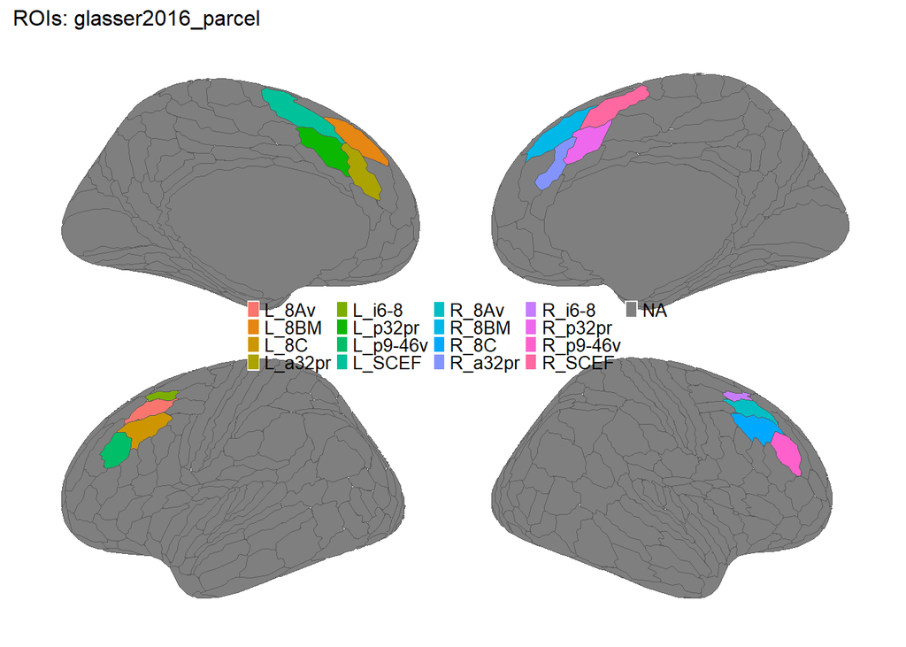

```r
atlas$data %>%
  ggplot() +
    geom_brain(
      aes(fill = ifelse(region %in% rois$region, region, NA)),
      atlas = atlas, position = position_brain(side ~ hemi)
      ) +
  labs(title = paste0("ROIs: ", roiset), fill = NULL) +
  theme_surface +
  theme(legend.text = element_text(size = 10))
```

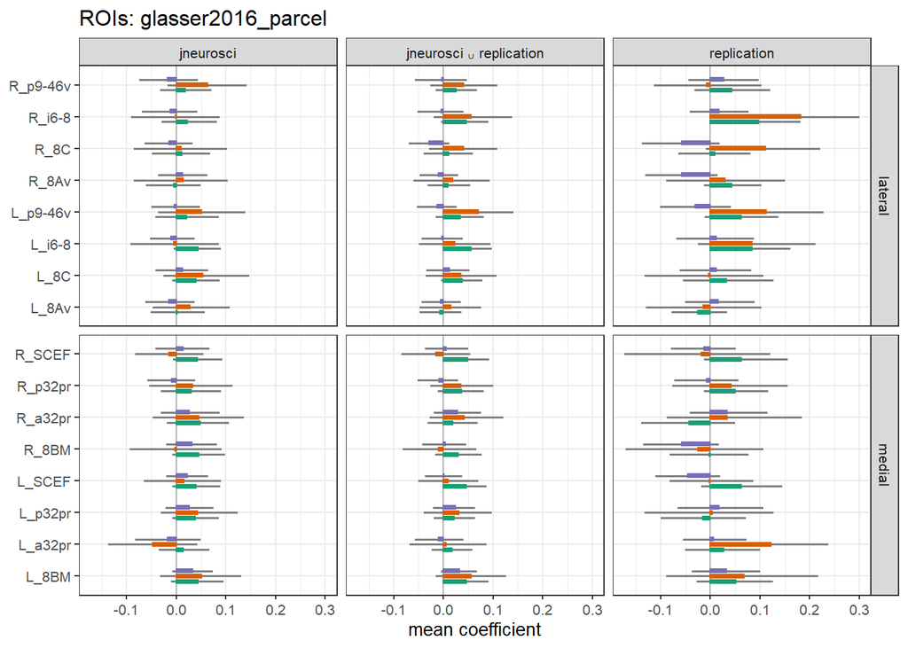

```r
dat_subjs_barplots %>%

  right_join(rois, by = "region") %>%

  ggplot(aes(region_nice, b, fill = term, color = term)) +
  geom_hline(yintercept = 0, color = "grey70") +
  stat_summary(
    fun.data = mean_cl_boot, geom = "errorbar", width = 0, size = 2/3, position = position_dodge(width = 0.5),
    color = "grey50"
    ) +
  stat_summary(fun = mean, geom = "col", width = 1/3, position = position_dodge(width = 0.5)) +

  scale_color_brewer(type = "qual", palette = 2) +
  scale_fill_brewer(type = "qual", palette = 2) +

  facet_grid(cols = vars(subjlist), rows = vars(location), scales = "free_y") +
  theme(
    #axis.text.x = element_text(angle = 90, hjust = 1, vjust = 0.5),
    legend.position = "none", axis.title.y = element_blank()
    ) +
    labs(y = "mean coefficient", title = paste0("ROIs: ", roiset)) +
  coord_flip()
```